# Solar Panel Proposal

Tyler Chia

## I: Abstract

As we enter the 3rd decade of the 21st century, the disastrous effects of climate change are becoming more and more clear and at some point, will become irreversible. According to NASA, carbon dioxide levels are the highest they have been in 650,000 years and the global temperature has risen 2 degrees Fahrenheit since 1880. In addition, the polar ice sheets are losing 427 billion metric tons per year and sea level rises 3.3 millimeters per year. Scientists have reported that global temperatures could reach an irreversible tipping point by 2030 if drastic measures are not taken to slow down the rapidly occurring climate change. In addition to environmental impact assessment, mitigation strategies must be set into place in order to insure that future generations will continue to be able to live on a habitable planet.

## II: Introduction

One way to minimize the amount of carbon released into the atmosphere is through the use of solar panels as a source of renewable energy. In this project, using a combination of data science methods and thorough research, I will propose a mitigation strategy that requires certain homeowners, based on the purchase price of their house, to install solar panels as a way of reducing carbon emissions. I will first use a dataset containing the annual number of metric tons of carbon emissions for certain cities in the United States. While it would be interesting to see the carbon emissions from every city in the U.S. this project will be on a smaller scale, only looking at prominent cities across the country. I will then look at more data containing median housing prices for these same specific cities. Exploring the data and using basic math will allow me to find the percentage change in carbon emissions per city as an indicator of how well my proposal will work. In the end, I would like to see the percentage change in carbon emissions per city if certain housing owners are required to install solar panels.

## III: Data

The dataset that I used was from the CDP which is an international non-profit organization based in the United Kingdom, Germany, and the U.S. The main purpose of the company is to help companies and cities disclose the environmental impact of major corporations. The data came as a CSV file and has 187 observations for the 187 cities in the dataset. In addition, the data has 16 variables.

- Account Number
- City Name
- Country
- City Short Name
- C40
- Reporting Year
- Measurement Year
- Primary Methodology
- Methodology Details
- Total City-Wide Emissions in Metric Tons of CO2
- Increase/Decrease From Last Year
- Reason for Increase/Decrease
- Current Population Year
- Population
- City Location
- Country Location

The main variables that I will be looking at are the City Name, Country, Total City-Wide Emissions of CO2, Population, and City Location.

## IV: Exploratory Data Analysis

### IV.I: Emissions Data

I first wanted to see how many cities from each country reported their emissions for 2016. The graph below displays this statistic. It is clear that out of the 187 cities that reported their carbon emissions in 2016, the United States has the most cities in this dataset at 63 cities. Other notable cities include Brazil, Canada, Italy, and Portugal.

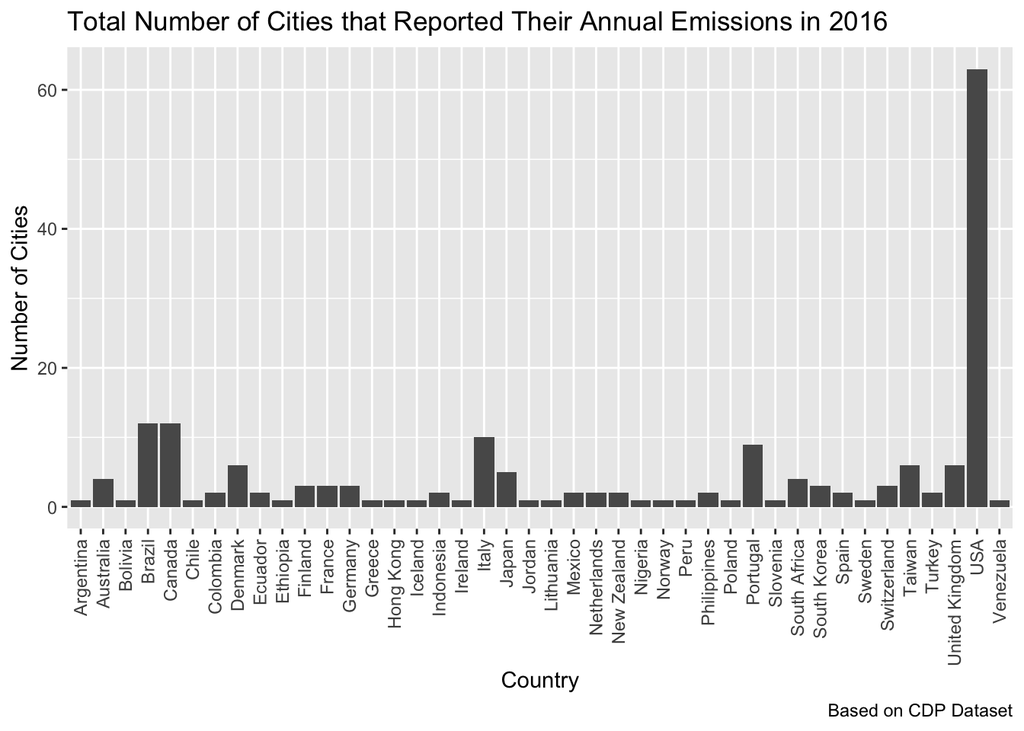

Doing a quick arrangement of the data allows me to see what cities within this 2016 dataset produced the most carbon emissions. Aside from New York City, it appears that the majority of these cities are located in Asia, which is good to note.

Top 5 Cities with Most CO2 Emissions

| City | Country | Total City-Wide Emissions (metric tonnes CO2e) |
| --- | --- | --- |
| Tokyo | Japan | 70,125,000 |
| Incheon | South Korea | 69,794,140 |
| Kaohsiung | Taiwan | 58,755,764 |
| New York City | USA | 49,385,508 |
| Seoul | South Korea | 47,612,664 |

After looking at the dataset a little more, I wanted to plot the location of all these cities on a map so I could see if there were any trends in terms of location for the cities that reported their emissions. However, I noticed that the city location variable in the dataset was one long string containing both the longitude and latitude coordinate. Because of this, I was forced to split the column into two separate variables: Longitude and Latitude. After this, I removed the parenthesis from the columns so my data was ready to be plotted on a world map.

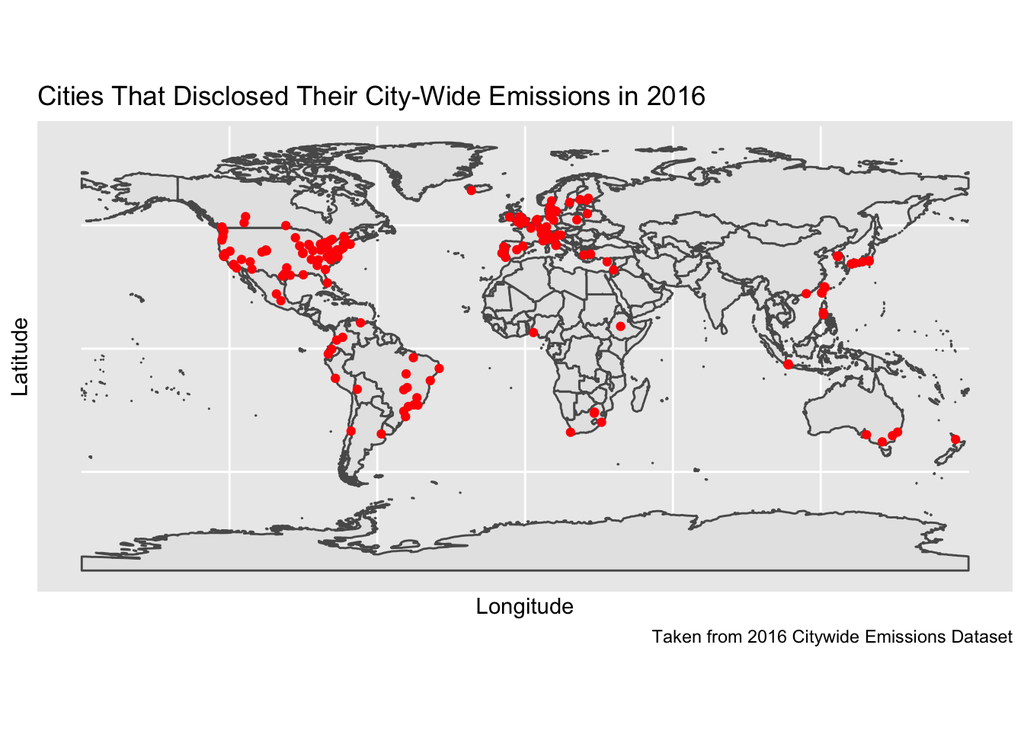

Once I plotted all the cities in the dataset, I moved on to the next step which was to isolate all the United States cities as these are the cities that I will be looking at when comparing them to housing data. Once I separated all 63 of the U.S. cities from the rest of them, I went ahead and plotted them on a map of the continental United States due to the fact that no cities in Alaska, Hawaii, or Puerto Rico were reported in the dataset.

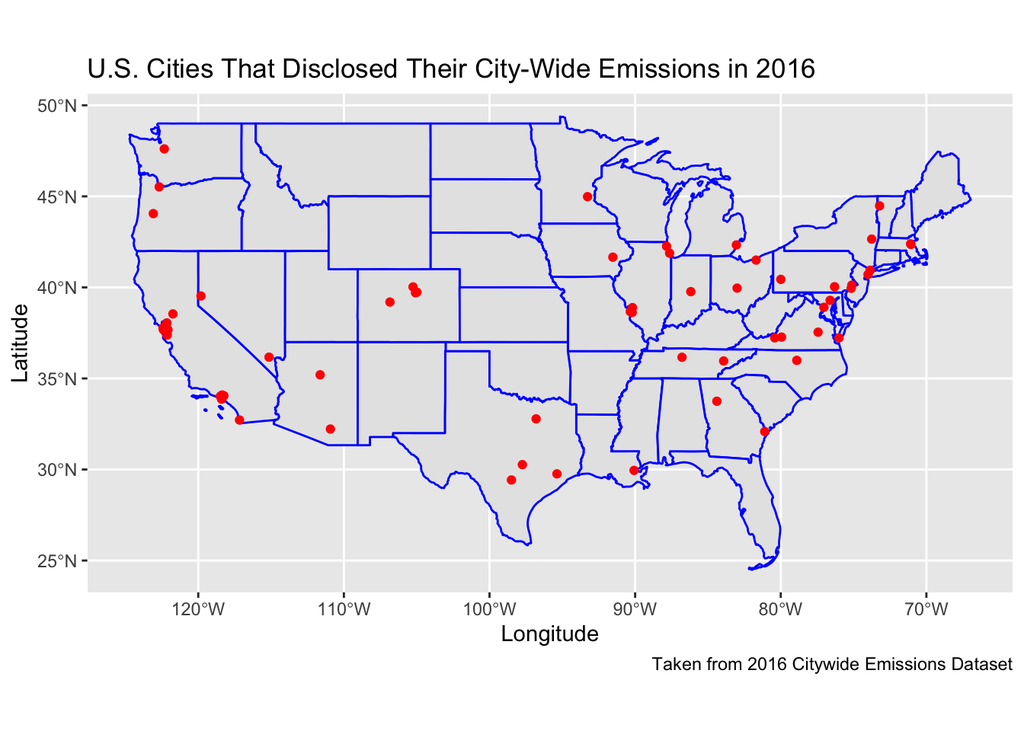

I then wanted to see which cities in the United States were producing the most carbon emissions according to this 2016 dataset. From what I can tell, all these top 5 cities are high in population and are pretty industrial cities.

Top 5 U.S. Cities with Most CO2 Emissions

| City | Country | Total City-Wide Emissions (metric tonnes CO2e) |
| --- | --- | --- |
| New York City | USA | 49,385,508 |
| Chicago | USA | 33,500,000 |
| Houston | USA | 33,428,301 |
| Las Vegas | USA | 29,657,130 |
| Los Angeles | USA | 29,024,807 |

Next, I wanted to see which cities had the most emissions per capita in order to determine if there was a relationship between the amount of CO2 emissions and the population. This population portion of the dataset was taken from different years with the earliest being 2010 and the latest being 2016. As you can see in the chart below, the only city that remains from the top 5 from the previous chart is Las Vegas, Nevada.

Top 5 U.S. Cities with Most CO2 Emissions Per Capita

| City | Total City-Wide Emissions (metric tonnes CO2e) | Current Population Year | Current Population | CO2 Tonnes Per Capita |
| --- | --- | --- | --- | --- |
| Las Vegas | 29,657,130 | 2,016 | 621,970 | 47.68257 |
| Aspen and Pitkin County | 394,341 | 2,010 | 8,427 | 46.79494 |
| Brisbane, CA | 148,025 | 2,015 | 4,603 | 32.15837 |
| Cleveland | 11,889,595 | 2,010 | 396,815 | 29.96256 |
| St Louis | 8,703,679 | 2,010 | 319,294 | 27.25914 |

### IV.II: Housing Data

For the housing portion of the data, obviously it would be impossible to find a dataset with the exact sales price of each house in each city. For that reason, as an alternative, I will be using Zillow.com in order to gain a rough estimate of the average price of what the average price of housing in each city is. I will be using Zillow’s Home Value Index. According to Zillow’s website, this index value is seasonally adjusted and only includes the middle price tier of homes. I took the most recent value they had on the site which was updated September 30, 2020. I will create a new vector for house prices and add that to the dataframe. Let us look at the top 5 cities in this dataset with the highest and lowest average price for housing.

Top 5 Most Expensive Cities for Housing

| City | Total City-Wide Emissions (metric tonnes CO2e) | Typical Housing Price |
| --- | --- | --- |
| Los Altos Hills | 57,243 | 4,398,248 |
| Palo Alto | 152,631 | 3,062,157 |
| Piedmont, CA | 43,442 | 2,237,911 |
| Aspen and Pitkin County | 394,341 | 2,113,927 |
| Santa Monica | 705,443 | 1,684,427 |

Top 5 Most Cheapest Cities for Housing

| City | Total City-Wide Emissions (metric tonnes CO2e) | Typical Housing Price |
| --- | --- | --- |
| Detroit | 10,329,322 | 42,486 |
| Alton, IL | 401,079 | 67,303 |
| Cleveland | 11,889,595 | 73,686 |
| St Louis | 8,703,679 | 139,496 |
| Baltimore | 7,579,144 | 156,106 |

Next, I need to add in the total number of houses in each city. I will create another vector for housing count and add it to the dataframe. In the chart below, I will display the cities in the dataframe with the most houses. Disclaimer: all of the housing counts are taken from the United States Census Bureau under households from 2014-2018. It should be noted that these housing counts are rough estimates.

Top 5 Cities With Most Houses

| City | Total City-Wide Emissions (metric tonnes CO2e) | Number of Households |
| --- | --- | --- |
| New York City | 49,385,508 | 3,154,103 |
| Los Angeles | 29,024,807 | 1,373,864 |
| Chicago | 33,500,000 | 1,056,118 |
| Houston | 33,428,301 | 848,340 |
| Philadelphia | 19,212,870 | 594,778 |

## V: Analysis and Discussion

According to [Energy Sage](https://news.energysage.com/how-much-does-the-average-solar-panel-installation-cost-in-the-u-s/), the average price for a 6 kilowatt solar panel system is $13,124 in the United States in 2020 after tax credits are taken from the original average price of $17,760. For this project, I have made the assumption that everyone will install a 6kW solar panel system due to the fact that it is the most frequently installed system according to the research I have done.

Now that I have the average price for a 6kW solar panel system, I will calculate the relationship between solar panel price and housing price per city as a percentage. This will give me an idea of what is affordable in each city based on the typical housing price. This percentage will be added to the dataframe as a new column.

Cost of 6kW Solar System as % of Typical Housing Price

| City | Typical Housing Price | Solar Panel Cost as % of House Price |
| --- | --- | --- |
| Lake Forest, IL | 753,653 | 1.741385 |
| Alton, IL | 67,303 | 19.499874 |
| Eugene | 354,073 | 3.706580 |
| Portland, OR | 479,166 | 2.738926 |
| Brisbane, CA | 1,050,747 | 1.249016 |

The chart above is shown just to give an idea of what the percentage of housing prices are the cost of a 6kW solar panel system. For example, the typical house in Brisbane, California costs $1,050,747. The average cost of a 6kw solar panel system is about 1.24% of the housing price.

Finding the amount of CO2 emissions prevented per solar panel system is a little more difficult to determine due to a number of factors. Firstly, it is difficult to estimate the production of solar panel system due to the fact that production can vary wildly based on location and placement. For example, places such as Seattle that obviously do not get a lot of constant sunlight will have less production from their solar panels than states such as Arizona or Nevada where there are deserts and lots of sunlight throughout the majority of the year. In addition, solar panel production depends on placement factors such as the angle or which side of the roof on which it is placed.

For these reasons, I will be using a VERY rough estimate taken from [Solar Reviews](https://www.solarreviews.com/blog/how-much-does-a-6kw-solar-power-system-cost-and-how-much-electricity-does-it-produce). According to their website, a 6kw solar panel system can produce between 6351kWh and 10,074kWh per year in optimal conditions. With all the varying factors that affect solar panels in mind, I am going to use the lower end of this spectrum as an estimate to how much a 6kW solar panel system produces during the course of one year.

Estimate: 6351kWh per year

The next issue I run into is converting this production number into an measure of how much CO2 is emitted into the atmosphere. The problem with this is that each state has different regulation laws which changes the amount of CO2 created by electricity production. I will be taking 2018 data from the [U.S. Energy Information Administration (EIA)](https://www.eia.gov/electricity/state/california/index.php) in order to determine how many pounds of carbon dioxide were released into the atmosphere for every 1 kWh of standard electricity produced. I will create a vector for these conversion rates and add it to the dataframe based on the state each city is in.

Pounds of CO2 Emitted per kWh Produced

| City | Conversion Rate (lbs CO2/kWh) |
| --- | --- |
| Lake Forest, IL | 0.846 |
| Alton, IL | 0.846 |
| Eugene | 0.302 |
| Portland, OR | 0.302 |
| Brisbane, CA | 0.491 |

The chart above is a quick sample of some of the conversion rates for the first five cities in the dataset.

As a side note, I would like to quickly point out that when inputting the conversion rates, I noticed that Vermont had the lowest conversion rate at 0.010 pounds of CO2 per kWh of electricity produced. I dug a little deeper and found that, “In 2019, Vermont generated 99.9% of its electricity from renewable resources, a larger share than in any other state.”

I will now multiply these conversion rates by my estimate of how much electricity is produced in one year by a 6kW solar panel system. Then, I will multiply this number by the number of houses per city. This result will give me the total amount of CO2 in pounds reduced if every house in the city implemented a 6kW solar panel system.

$$CO2 Saved (pounds) = 6351 kWh \cdot Conversion Rate \cdot Number of Houses$$

I then have to convert this number from pounds to metric tons in order to compare it to the total city-wide emissions from 2016.

$$CO2Saved(Metric Tons) = CO2Saved(pounds) / 2204.6$$

CO2 Saved if Every House Has 6kW Solar System

| City | CO2 Saved (metric tons) |
| --- | --- |
| Lake Forest, IL | 16,762.73 |
| Alton, IL | 28,007.75 |
| Eugene | 59,903.85 |
| Portland, OR | 230,052.36 |
| Brisbane, CA | 2,575.75 |

Chart above containing the first five cities in the dataset is given as an example for how much less carbon emissions are emitted if every house in each city were to install a 6kW solar panel system.

Now that I have the amount of CO2 saved per year per city, I would like to calculate the change that would occur in the total city-wide emissions if every housing owner were to install this solar panel system.

Percent Decrease in CO2 Emissions

| City | Percent Decrease |
| --- | --- |
| Lake Forest, IL | 4.1660620 |
| Alton, IL | 6.9831017 |
| Eugene | 4.7923080 |
| Portland, OR | 3.2984574 |
| Brisbane, CA | 1.7400778 |
| Roanoke | 4.7416022 |
| Austin | 8.2480218 |
| Durham | 6.3894509 |
| San Antonio | 9.6606791 |
| Emeryville, CA | 5.4444217 |
| Hayward | 6.4428487 |
| Davis, CA | 9.9876627 |
| Iowa | 7.9062632 |
| Indianapolis | 79.3800986 |
| Aspen and Pitkin County | 3.1018039 |
| Hermosa Beach, CA | 10.0311410 |
| Columbus | 12.5845538 |
| Burlington | 0.1151009 |
| Flagstaff | 5.1589139 |
| Dallas | 8.9648058 |
| Houston | 7.7495024 |
| Boulder | 9.8376686 |
| Abington | 7.6801964 |
| Albany | 4.5256216 |
| Arlington, VA | 9.3878990 |
| Yonkers | 8.0125318 |
| Denver | 13.0728473 |
| Atlanta | 5.9412601 |
| Knoxville | 4.5278452 |
| Baltimore | 8.1202984 |
| San Diego | 5.6410061 |
| Benicia | 2.2858888 |
| Blacksburg | 7.7867179 |
| Detroit | 8.4746930 |
| Boston | 10.2162840 |
| Chicago | 7.6833446 |
| Cleveland | 5.5850497 |
| District of Columbia | 13.0346451 |
| Lakewood | 15.1139474 |
| Lancaster, PA | 13.7098633 |
| Las Vegas | 1.7087281 |
| Los Altos Hills | 7.5439399 |
| Los Angeles | 6.6952717 |
| University City, MO | 15.0890946 |
| Minneapolis | 11.1390176 |
| Nashville and Davidson | 4.9696023 |
| New Orleans | 10.6493416 |
| New York City | 8.5370266 |
| Oakland | 8.3555584 |
| Palo Alto | 24.2913254 |
| Savannah | 3.9604713 |
| Philadelphia | 7.0185871 |
| Piedmont, CA | 12.8546760 |
| West Hollywood | 5.7086861 |
| St Louis | 7.8891186 |
| Pittsburgh | 6.4325991 |
| Reno | 4.9857343 |
| Richmond, VA | 6.3383109 |
| San Francisco | 9.4532948 |
| Santa Monica | 9.1205109 |
| Seattle | 3.5865202 |
| Somerville, MA | 13.0420675 |
| Tucson | 8.3813849 |

Just to reiterate, the chart above shows the percentage decrease in CO2 emissions from 2016 if every home in each city were required to install a 6kW solar panel system.

One thing that I noticed as an outlier was Indianapolis as it had a 79% decrease in carbon emissions. At first, I thought my numbers were off so I checked my math. However, it turns out that in 2018 in Indiana, for every kWh of electricity produced, 1.775 pounds of CO2 were released, which is significantly higher than most cities. When you take away all that CO2 by implementing solar panels, the percent decrease would therefore be higher than normal.

Getting to my next step, I want to calculate the percentage decrease for all 63 of these cities combined.

Percent Decrease in CO2 Emissions For all 63 Reported Cities

| Total Emissions 2016 | Total Emissions with Solar Panel Plan | Total CO2 Saved | Percent Decrease |
| --- | --- | --- | --- |
| 431,948,409 | 398,189,422 | 33,758,987 | 7.815514 |

If all 63 cities had every house install a 6kW solar panel system, the total number of CO2 emissions would decrease by 7.8%.

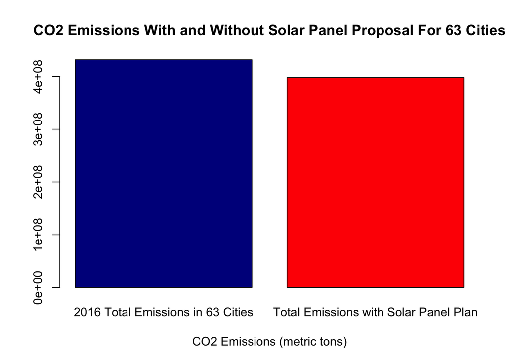

## VII: References

1. https://data.cdp.net/Emissions/2016-Citywide-Emissions-Map/iqbu-zjaj
2. https://climate.nasa.gov/
3. https://abcnews.go.com/International/united-nations-report-details-looming-climate-crisis/story?id=58354235
4. https://www.zillow.com/
5. https://www.point2homes.com/US/Neighborhood/IL/Lake-Forest-Demographics.html
6. https://www.neighborhoodscout.com/il/alton/real-estate
7. https://www.census.gov/quickfacts/
8. https://en.wikipedia.org/wiki/Brisbane,_California
9. https://news.energysage.com/how-much-does-the-average-solar-panel-installation-cost-in-the-u-s/
10. https://energysolutionsolar.com/blog/how-much-co2-does-solar-panel-save
11. https://www.eia.gov/electricity/state/california/index.php
12. https://www.solarreviews.com/blog/how-much-does-a-6kw-solar-power-system-cost-and-how-much-electricity-does-it-produce
13. https://www.eia.gov/state/print.php?sid=VT

## VIII: Appendix

```r
library(tidyverse)
library(sf)
library(readr)
library(USAboundaries)
library(USAboundariesData)
library(rnaturalearth)
library(rnaturalearthdata)
library(scales)
emissions <- read_csv("~/github/Solar-Panel-Proposal/data/2016_-_Citywide_Emissions__Map.csv")

emissions = emissions %>%
  separate(`City Location`, c('Lat', 'Long'), sep = ",")

emissions$Lat <- substring(emissions$Lat, 2)
emissions$Long <- substr(emissions$Long, 1, nchar(emissions$Long)-1)

emissions$Lat = as.numeric(emissions$Lat)
emissions$Long = as.numeric(emissions$Long)

no_cities = emissions %>%
  group_by(Country) %>%
  summarise(Number_of_Cities = n())
ggplot(data = no_cities, aes(x = Country, y= Number_of_Cities), las=2) +
  geom_bar(stat="identity") +
  theme(axis.text.x=element_text(angle=90,hjust=1,vjust=0.5)) +
  labs(x = 'Country',
       y = 'Number of Cities',
       title = 'Total Number of Cities that Reported Their Annual Emissions in 2016',
       caption = 'Based on CDP Dataset')
top5 = emissions %>%
  select(`City Short Name`, Country, `Total City-wide Emissions (metric tonnes CO2e)`) %>%
  arrange(-`Total City-wide Emissions (metric tonnes CO2e)`) %>%
  head(5)

knitr::kable(top5, caption = "Top 5 Cities with Most CO2 Emissions", col.names = c("City","Country","Total City-Wide Emissions (metric tonnes CO2e)"), "simple", format.args = list(big.mark = ",",
  scientific = FALSE))
hos_sf = st_as_sf(emissions, coords = c("Long", "Lat"), crs = 4326)

world = ne_countries(scale = 'medium', returnclass = 'sf') %>%
  st_transform(4326)

ggplot(data = world) +
  geom_sf() +
  geom_sf(data = hos_sf, color = "red") +
  labs(title = "Cities That Disclosed Their City-Wide Emissions in 2016",
       x = "Longitude",
       y = "Latitude",
       caption = "Taken from 2016 Citywide Emissions Dataset")
USA = USAboundaries::us_states() %>%
  st_transform(4326) %>%
  filter(name != 'Alaska' & name != 'Puerto Rico' & name != 'Hawaii')

counties = USAboundaries::us_counties() %>%
  st_transform(4326) %>%
  filter(state_name != 'Alaska' & state_name != 'Puerto Rico' & state_name != 'Hawaii')

us_emissions <- hos_sf %>%
  filter(Country == 'USA')

ggplot() +
  geom_sf(data = USA, color = "blue") +
  geom_sf(data = us_emissions, color = "red") +
  coord_sf(datum = st_crs(us_emissions)) +
  labs(title = "U.S. Cities That Disclosed Their City-Wide Emissions in 2016",
       x = "Longitude",
       y = "Latitude",
       caption = "Taken from 2016 Citywide Emissions Dataset")
top5US = emissions %>%
  filter(Country == 'USA') %>%
  select(`City Short Name`, Country, `Total City-wide Emissions (metric tonnes CO2e)`) %>%
  arrange(-`Total City-wide Emissions (metric tonnes CO2e)`) %>%
  head(5)


knitr::kable(top5US, caption = "Top 5 U.S. Cities with Most CO2 Emissions", col.names = c("City","Country","Total City-Wide Emissions (metric tonnes CO2e)"), "simple", format.args = list(big.mark = ",",
  scientific = FALSE))
USAemissions = emissions %>%
  filter(Country == 'USA')

top5percapita = USAemissions %>%
  mutate(Per_Capita = `Total City-wide Emissions (metric tonnes CO2e)` / `Current Population`) %>%
  select(`City Short Name`, `Total City-wide Emissions (metric tonnes CO2e)`, `Current Population Year`, `Current Population`, Per_Capita) %>%
  arrange(-Per_Capita) %>%
  head(5)

knitr::kable(top5percapita, caption = "Top 5 U.S. Cities with Most CO2 Emissions Per Capita", col.names = c("City","Total City-Wide Emissions (metric tonnes CO2e)", "Current Population Year", "Current Population", "CO2 Tonnes Per Capita"), "simple", format.args = list(big.mark = ",",
  scientific = FALSE))
prices <- c(753653, 67303, 354073, 479166, 1050747, 177683, 426750, 264923, 198162, 594405, 702173, 709630, 233312, 165692, 2113927, 711361, 180611, 357731, 400251, 238156, 196902, 770097, 259906, 189889, 754942, 549387, 466601, 296590, 213420, 156106, 675496, 656990, 274122, 42486, 659598, 278816, 73686, 641121, 457166, 259906, 296251, 4398248, 768046, 198764, 301333, 298039, 240091, 632271, 804577, 3062157, 190654, 200306, 2237911, 906839, 139496, 190589, 409375, 249656, 1405199, 1684427, 773508, 731656, 219800)

USAemissions$Price <- prices

top5price = USAemissions %>%
  select(`City Short Name`, `Total City-wide Emissions (metric tonnes CO2e)`, Price) %>%
  arrange(-Price) %>%
  head(5)
bot5price = USAemissions %>%
  select(`City Short Name`, `Total City-wide Emissions (metric tonnes CO2e)`, Price) %>%
  arrange(Price) %>%
  head(5)

knitr::kable(top5price, caption = "Top 5 Most Expensive Cities for Housing", col.names = c("City","Total City-Wide Emissions (metric tonnes CO2e)", "Typical Housing Price"),"simple", format.args = list(big.mark = ",",
  scientific = FALSE))
knitr::kable(bot5price, caption = "Top 5 Most Cheapest Cities for Housing", col.names = c("City","Total City-Wide Emissions (metric tonnes CO2e)", "Typical Housing Price"),"simple", format.args = list(big.mark = ",",
  scientific = FALSE))
housecount <- c(6878, 11492, 68855, 264428, 1821, 42037, 370043, 123444, 497794, 6456, 47768, 24597, 29975, 335373, 3079, 8979, 352543, 16197, 23610, 505816, 848340, 42643, 20841, 41207, 104716, 74848, 294258, 199478, 79579, 238436, 503463, 11130, 13436, 260383, 266247, 1056118, 169365, 281322, 65737, 22118, 226396, 3053, 1373864, 15468, 173916, 268061, 154036, 3154103, 161483, 26212, 53187, 594778, 3948, 23538, 140455, 136275, 98844, 89846, 359673, 45487, 323446, 32851, 210816)

USAemissions$Num_Houses <- housecount

top5count = USAemissions %>%
  select(`City Short Name`, `Total City-wide Emissions (metric tonnes CO2e)`, Num_Houses) %>%
  arrange(-Num_Houses) %>%
  head(5)

knitr::kable(top5count, caption = "Top 5 Cities With Most Houses", col.names = c("City","Total City-Wide Emissions (metric tonnes CO2e)", "Number of Households"),"simple", format.args = list(big.mark = ",",
  scientific = FALSE))
USAemissions = USAemissions %>%
  mutate(percent_of_price = (13124 / Price) * 100)

percentprice = USAemissions %>%
  select(`City Short Name`, Price, percent_of_price) %>%
  head(5)

knitr::kable(percentprice, caption = "Cost of 6kW Solar System as % of Typical Housing Price", col.names = c("City","Typical Housing Price", "Solar Panel Cost as % of House Price"),"simple", format.args = list(big.mark = ",",
  scientific = FALSE))
convertrate = c(0.846, 0.846, 0.302, 0.302, 0.491, 0.772, 1.060, 0.814, 1.060, 0.491, 0.491, 0.491, 1.189, 1.775, 1.379, 0.491, 1.361, 0.010, 0.919, 1.060, 1.060, 1.379, 0.787, 0.464, 0.772, 0.464, 1.379, 0.933, 0.790, 0.896, 0.491, 0.491, 0.772, 1.167, 0.808, 0.846, 1.361, 1.188, 1.379, 0.787, 0.777, 0.491, 0.491, 1.697, 1.066, 0.790, 1.094, 0.464, 0.491, 0.491, 0.933, 0.787, 0.491, 0.491, 1.697, 0.787, 0.777, 0.772, 0.491, 0.491, 0.201, 0.808, 0.919)

USAemissions$conversion_rate = convertrate

conversionrate = USAemissions %>%
  select(`City Short Name`, conversion_rate) %>%
  head(5)

knitr::kable(conversionrate, caption = "Pounds of CO2 Emitted per kWh Produced", col.names = c("City", "Conversion Rate (lbs CO2/kWh)"),"simple")
USAemissions = USAemissions %>%
  mutate(CO2_saved_lbs = 6351 * conversion_rate * Num_Houses)

USAemissions = USAemissions %>%
  mutate(CO2_saved_tons = CO2_saved_lbs / 2204.6)

amountsaved = USAemissions %>%
  select(`City Short Name`, CO2_saved_tons) %>%
  head(5)

knitr::kable(amountsaved, caption = "CO2 Saved if Every House Has 6kW Solar System", col.names = c("City", "CO2 Saved (metric tons)"),"simple", format.args = list(big.mark = ",",
  scientific = FALSE))
USAemissions = USAemissions %>%
  mutate(percentchange = ((`Total City-wide Emissions (metric tonnes CO2e)` - (`Total City-wide Emissions (metric tonnes CO2e)` - CO2_saved_tons)) / `Total City-wide Emissions (metric tonnes CO2e)`) * 100)

percentdec = USAemissions %>%
  select(`City Short Name`, percentchange)

knitr::kable(percentdec, caption = "Percent Decrease in CO2 Emissions", col.names = c("City", "Percent Decrease"),"simple")
final = data.frame("Total City-Wide Emissions" = 431948409, "Total City-Wide Emissions w Panels" = 398189422, "Total CO2 Saved" = 33758987)

final1 = final %>%
  mutate(percentchanger = (Total.CO2.Saved / Total.City.Wide.Emissions) * 100)
final2 = final %>%
  mutate(Emissions_with = Total.City.Wide.Emissions - Total.CO2.Saved) %>%
  select(Total.City.Wide.Emissions, Emissions_with)

knitr::kable(final1, caption = "Percent Decrease in CO2 Emissions For all 63 Reported Cities", col.names = c("Total Emissions 2016", "Total Emissions with Solar Panel Plan", "Total CO2 Saved", "Percent Decrease"), "simple", format.args = list(big.mark = ",", scientific = FALSE))
counts <- c(final2$Total.City.Wide.Emissions, final2$Emissions_with)
barplot(counts, main="CO2 Emissions With and Without Solar Panel Proposal For 63 Cities",
  xlab="CO2 Emissions (metric tons)", col=c("darkblue","red"), names.arg= c("2016 Total Emissions in 63 Cities", "Total Emissions with Solar Panel Plan"))
```